# 09_mult_mats_diagram

## 09_mult_mats_diagram

#### Question

1. Let matrices $A$ and $B$ be defined below.

   $$A = \begin{bmatrix}
   2 & 4 & 5 & 5\\
   4 & 5 & 3 & 5\\
   3 & 2 & 0 & 2
   \end{bmatrix}$$
   $$B = \begin{bmatrix}
   4 & 1 & 4 & 1 & 3\\
   3 & 5 & 0 & 4 & 4\\
   5 & 0 & 4 & 5 & 6\\
   5 & 3 & 3 & 6 & 1
   \end{bmatrix}$$

   A third matrix, $C$, is equal to the [product](https://en.wikipedia.org/wiki/Matrix_multiplication) $AB$. A student set up a diagram to help find the product; they are missing a single element in $C$, element $c_{3,3}$.

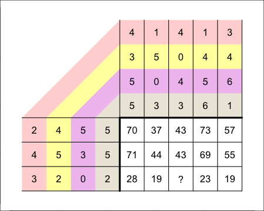

   What is $c_{3,3}$?

#### Question

2. Let matrices $A$ and $B$ be defined below.

   $$A = \begin{bmatrix}
   1 & 0 & 5 & 4\\
   3 & 6 & 2 & 1\\
   6 & 1 & 2 & 0
   \end{bmatrix}$$
   $$B = \begin{bmatrix}
   3 & 4 & 6 & 6 & 3\\
   0 & 4 & 2 & 1 & 0\\
   1 & 3 & 2 & 3 & 2\\
   2 & 1 & 6 & 4 & 4
   \end{bmatrix}$$

   A third matrix, $C$, is equal to the [product](https://en.wikipedia.org/wiki/Matrix_multiplication) $AB$. A student set up a diagram to help find the product; they are missing a single element in $C$, element $c_{2,2}$.

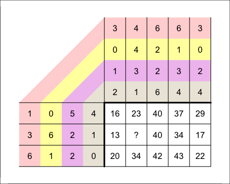

   What is $c_{2,2}$?

#### Question

3. Let matrices $A$ and $B$ be defined below.

   $$A = \begin{bmatrix}
   1 & 6 & 0 & 3\\
   1 & 1 & 6 & 4\\
   2 & 3 & 2 & 0
   \end{bmatrix}$$
   $$B = \begin{bmatrix}
   0 & 3 & 5 & 0 & 0\\
   6 & 4 & 0 & 5 & 4\\
   6 & 5 & 1 & 3 & 2\\
   6 & 4 & 4 & 1 & 3
   \end{bmatrix}$$

   A third matrix, $C$, is equal to the [product](https://en.wikipedia.org/wiki/Matrix_multiplication) $AB$. A student set up a diagram to help find the product; they are missing a single element in $C$, element $c_{2,5}$.

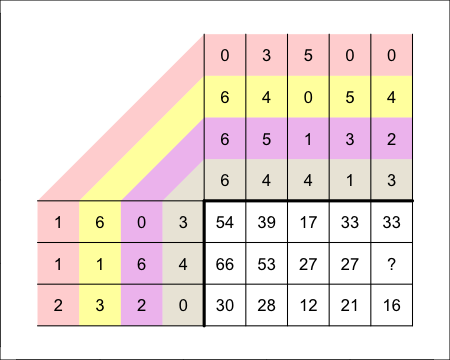

   What is $c_{2,5}$?

#### Question

4. Let matrices $A$ and $B$ be defined below.

   $$A = \begin{bmatrix}
   4 & 1 & 0 & 2\\
   5 & 4 & 0 & 4\\
   4 & 6 & 3 & 0
   \end{bmatrix}$$
   $$B = \begin{bmatrix}
   4 & 1 & 3 & 4 & 6\\
   4 & 4 & 6 & 0 & 2\\
   6 & 3 & 2 & 5 & 5\\
   0 & 6 & 3 & 6 & 5
   \end{bmatrix}$$

   A third matrix, $C$, is equal to the [product](https://en.wikipedia.org/wiki/Matrix_multiplication) $AB$. A student set up a diagram to help find the product; they are missing a single element in $C$, element $c_{1,2}$.

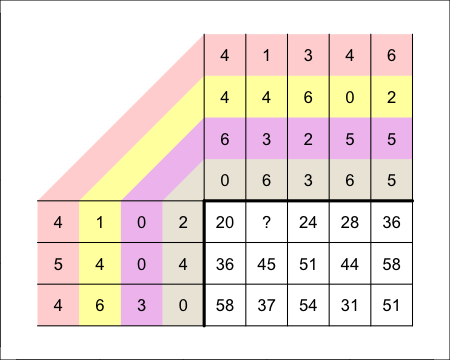

   What is $c_{1,2}$?

#### Question

5. Let matrices $A$ and $B$ be defined below.

   $$A = \begin{bmatrix}
   2 & 0 & 3 & 5\\
   3 & 6 & 4 & 1\\
   1 & 0 & 5 & 4
   \end{bmatrix}$$
   $$B = \begin{bmatrix}
   6 & 3 & 6 & 3 & 6\\
   0 & 4 & 4 & 4 & 5\\
   4 & 3 & 2 & 3 & 2\\
   2 & 6 & 3 & 2 & 1
   \end{bmatrix}$$

   A third matrix, $C$, is equal to the [product](https://en.wikipedia.org/wiki/Matrix_multiplication) $AB$. A student set up a diagram to help find the product; they are missing a single element in $C$, element $c_{3,1}$.

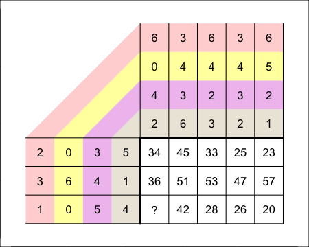

   What is $c_{3,1}$?

#### Question

6. Let matrices $A$ and $B$ be defined below.

   $$A = \begin{bmatrix}
   5 & 5 & 2 & 1\\
   4 & 1 & 0 & 5\\
   0 & 4 & 5 & 5
   \end{bmatrix}$$
   $$B = \begin{bmatrix}
   6 & 0 & 3 & 2 & 1\\
   4 & 3 & 2 & 2 & 0\\
   5 & 5 & 1 & 3 & 4\\
   5 & 5 & 5 & 3 & 1
   \end{bmatrix}$$

   A third matrix, $C$, is equal to the [product](https://en.wikipedia.org/wiki/Matrix_multiplication) $AB$. A student set up a diagram to help find the product; they are missing a single element in $C$, element $c_{3,2}$.

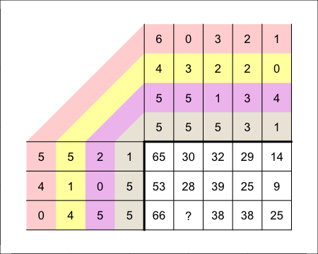

   What is $c_{3,2}$?

#### Question

7. Let matrices $A$ and $B$ be defined below.

   $$A = \begin{bmatrix}
   4 & 6 & 6 & 2\\
   4 & 6 & 2 & 6\\
   5 & 2 & 2 & 6
   \end{bmatrix}$$
   $$B = \begin{bmatrix}
   0 & 0 & 4 & 0 & 4\\
   5 & 4 & 1 & 5 & 3\\
   3 & 4 & 6 & 3 & 3\\
   4 & 3 & 1 & 3 & 2
   \end{bmatrix}$$

   A third matrix, $C$, is equal to the [product](https://en.wikipedia.org/wiki/Matrix_multiplication) $AB$. A student set up a diagram to help find the product; they are missing a single element in $C$, element $c_{2,4}$.

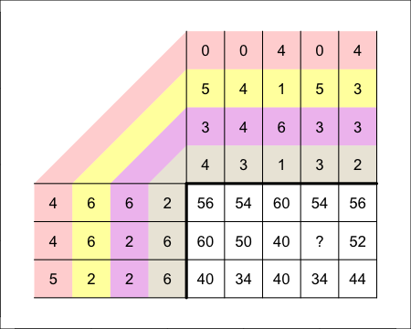

   What is $c_{2,4}$?

#### Question

8. Let matrices $A$ and $B$ be defined below.

   $$A = \begin{bmatrix}
   6 & 3 & 3 & 6\\
   1 & 6 & 5 & 6\\
   0 & 3 & 3 & 2
   \end{bmatrix}$$
   $$B = \begin{bmatrix}
   1 & 4 & 6 & 3 & 5\\
   3 & 6 & 2 & 3 & 0\\
   4 & 2 & 4 & 5 & 1\\
   6 & 1 & 4 & 1 & 2
   \end{bmatrix}$$

   A third matrix, $C$, is equal to the [product](https://en.wikipedia.org/wiki/Matrix_multiplication) $AB$. A student set up a diagram to help find the product; they are missing a single element in $C$, element $c_{3,1}$.

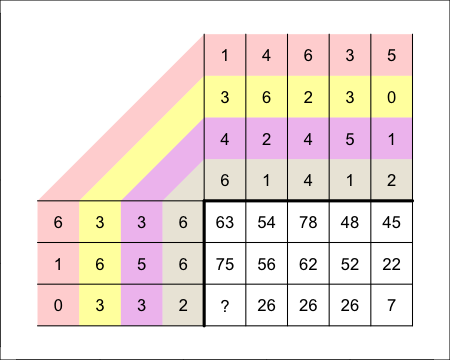

   What is $c_{3,1}$?